# Catching Stolen Cars with Math

How Statistics Helps Police Find Stolen Vehicles — and Leave Innocent Drivers Alone

Jessica Minnier, OHSU Knight Cancer Institute

2026-05-14

## Today’s Question

How can math help police catch more stolen cars

while pulling over **fewer innocent drivers**?

## Who Am I?

- **Jessica Minnier**, biostatistician at OHSU (Oregon Health & Science University)
- I mostly study cancer data 🧬
- But the *same statistical tools* work for almost any “predict an outcome from clues” problem
- Today’s project: data from **Portland Police Bureau** Stolen Vehicle Operations (SVO)

Statistics is a transferable superpower. 🦸

[figure not shown]

## The Problem

**Cars get stolen. A lot.**

- Police want to recover them
- They can’t pull over *every* car
- Pulling over innocent drivers is bad: wastes time, scares people, damages trust

**Goal:**

Pull over the cars **most likely** to be stolen.

Leave the rest alone.

*How? With* **DATA.**

## What Officers Record on Each Stop

When police make a stop during a stolen vehicle operation (SVO), they record:

- **Outcomes:** Was the car stolen? Were there warrants? Was a gun recovered?
- **“Enrichment factors”:** observable clues *before* the stop
- **Vehicle info:** make, model, year, color

Each row of the dataset = one stop. As of November 2025, we have **1,930 stops** across 5 agencies.

## What’s an “Enrichment Factor”?

A clue police can spot from outside the car. There are **39** of them. Examples:

**License plates:**

- Missing front plate
- Missing back plate
- Plate doesn’t match the car
- Plate reported stolen

**Vehicle behavior / appearance:**

- Eluding police (running)
- Broken windows
- Tinted windows
- Driver hiding their face

The big question: **do these clues actually predict stolen?**

## Picture the Data Structure

1 row = 1 stop. Columns = clues + outcome.

| Stop | Elude | Broken windows | Stolen plate | More clues | Stolen? |
| --- | --- | --- | --- | --- | --- |
| #1 | Yes | No | No | … | YES |
| #2 | No | No | No | … | NO |
| #3 | Yes | Yes | Yes | … | YES |
| #4 | Yes | No | No | … | NO |
| … | … | … | … | … | … |

This shape — rows = observations, columns = variables — is what **all** of statistics works with.

## The Sample Grew Over Time

Sample size growing over time

| Period | Stops | Agencies | Cumulative |
| --- | --- | --- | --- |
| Mar 2022 – Oct 2022 | 561 | PPB only | 561 |
| Oct 2022 – Apr 2023 | 255 | PPB only | 816 |
| Apr 2023 – Dec 2023 | 428 | PPB only | 1244 |
| Jan 2024 – Aug 2024 | 334 | PPB only | 1578 |
| Sept 2024 – Nov 2025 | 352 | PPB + 4 more agencies | 1930 |

More data → more reliable estimates. Adding other agencies (Gresham, Multnomah County, etc.) lets us check whether patterns hold beyond just Portland.

⚠️ But this is **not a random sample** of all cars on the road — these cars were *already flagged as suspicious*. A key idea in AP Stats: **sampling bias** affects what we can conclude.

## A Proportion Is Just a Fraction

$$\text{proportion} = \frac{\text{count of "yes"}}{\text{total count}}$$

In our data of **1,930 stops**:

- **~28%** of stopped vehicles were stolen
- **~21%** had outstanding warrants
- **~5%** had a gun recovered

So among SVO stops, roughly **1 in 4** ends up being a stolen car. Can we do better?

## Comparing Proportions: Does a Clue Help?

**Among cars where the driver eluded police:**

- ~55% turned out to be stolen

**Among cars that did NOT elude:**

- ~21% turned out to be stolen

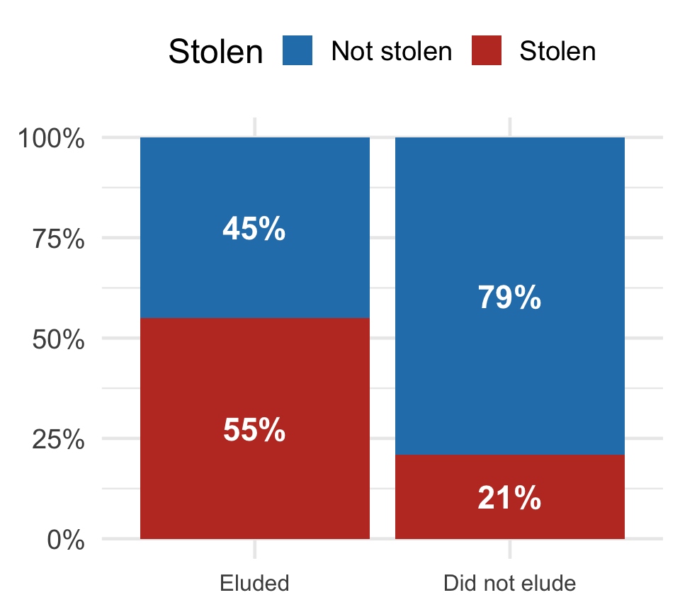

Eluding police **more than doubles** the proportion stolen. That’s a strong signal!

## From Proportions to Odds

**Tip**

- **Proportion** (or probability): out of *everyone*, how many “yes”?
  - $P = \dfrac{\text{stolen}}{\text{stolen} + \text{not stolen}}$
- **Odds**: ratio of “yes” to “no”
  - $\text{odds} = \dfrac{\text{stolen}}{\text{not stolen}} = \dfrac{P}{1-P}$

If 55% are stolen: odds = $\frac{0.55}{0.45} \approx 1.22$ (a bit more than 1-to-1)

If 21% are stolen: odds = $\frac{0.21}{0.79} \approx 0.27$ (about 1-to-4)

## Why Odds? Because of **Odds Ratios** (OR)

$$\text{Odds Ratio} = \frac{\text{odds of stolen WITH the clue}}{\text{odds of stolen WITHOUT the clue}}$$

For “elude”: $\text{OR} = \dfrac{1.22}{0.27} \approx 4.5$

**Interpretation:** A car that eludes police has about **4.5× higher odds** of being stolen than one that doesn’t.

- OR = 1 → the clue doesn’t matter
- OR > 1 → the clue **raises** odds of stolen
- OR < 1 → the clue **lowers** odds of stolen

## Reading an Odds Ratio Plot

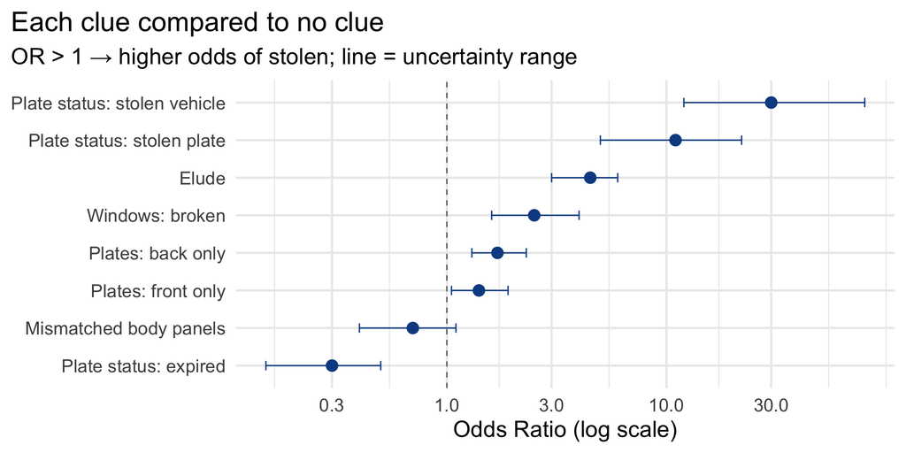

The horizontal line is a **confidence interval** — the range of plausible values. If it crosses 1, the clue may not really matter.

## What If a Car Has Several Clues?

A real car might be eluding police AND have a broken window AND missing plates.

Do all three clues each add information? Or do they overlap?

We need a **model** that uses *all the clues together*.

## What’s a “Model” with Predictors and an Outcome?

A statistical **model** is a rule that takes in **predictors** (inputs / clues) and estimates the chance of an **outcome**.

$$\color{#c0392b}{P(\text{Stolen})} = f(\color{#0E4D92}{\text{plates, windows, elude, } \ldots})$$

red = **outcome** · blue = **predictors**

Think of it like a recipe:

- **Ingredients** → predictors (the clues)
- **Recipe** → the model (the math)
- **Dish** → the predicted probability of being stolen

## Logistic Regression: The Engine

For yes/no outcomes (stolen / not stolen), the workhorse model is **logistic regression**.

The model assigns each clue a **weight**:

$$\log(\text{odds of stolen}) = \beta_0 + \beta_1 \cdot \text{clue}_1 + \beta_2 \cdot \text{clue}_2 + \dots$$

- $\beta > 0$: clue raises stolen odds
- $\beta < 0$: clue lowers stolen odds
- $e^{\beta}$ = the odds ratio (the thing we just learned!)

Don’t worry about the algebra — the **idea** is what matters: *each clue gets a weight.*

## With 39 Clues, We Have a Problem 😬

- We have **39 enrichment factors**
- Some are **redundant** (e.g., “elude high-speed” and “elude into blocks” usually go together)
- Including all 39 can make the model **overfit** — it memorizes our specific data and fails on new cars
- We need a way to keep only the **most useful** clues

## Enter the LASSO 🤠

**L**east **A**bsolute **S**hrinkage and **S**election **O**perator

A clever twist on logistic regression that:

1. Tries to fit the data well (like regular regression), **AND**
2. **Penalizes** the model for having too many predictors

Less-useful clues get their weight squeezed **all the way to zero** — the LASSO *drops* them automatically.

## What the LASSO Picked

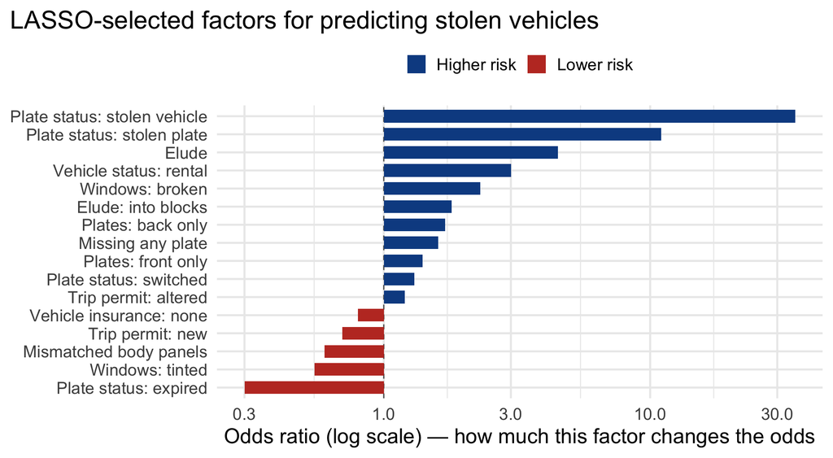

## Surprises in the Data

- **Tinted windows** *lowered* the odds — many factory tints aren’t a real signal
- **Expired plates** strongly *lowered* odds — that’s people who forgot to renew, not car thieves
- **Plate already flagged stolen** raises odds by **~35×** — the clearest possible clue

Statistics helps us **separate real signals from false ones** — including some that people might have *assumed* mattered but actually don’t.

## Is the Model Any Good?

The model gives every car a **predicted probability** of being stolen, from 0% to 100%.

We measure overall accuracy with one number, called **AUC** — short for “area under the curve.”

| AUC value | Quality |
| --- | --- |
| 0.5 | Coin flip — useless |
| 0.7 | Okay |
| **0.88** | **Our stolen-vehicle model** ✅ |
| 1.0 | Perfect (and unrealistic) |

## What Could This Mean in Practice?

- Without the model, only **~28%** of stops were stolen cars
- With the model guiding decisions, that hit rate could rise to **~65%**
- Fewer innocent drivers pulled over
- More stolen cars taken off the road

**A small statistical idea → a real-world impact.**

## Fairness Matters Too ⚖️

**Important**

A model that’s “accurate” overall can still be **unfair** to certain groups.

- We checked whether predicted probabilities behave similarly across groups of drivers
- Enrichment factors are about the **vehicle**, not the driver — that helps
- This is ongoing work

Statistics doesn’t just answer *“does it work?”* — it also asks *“**does it work fairly?**”*

## What We Did Today

1. Saw real **data structure** — rows of stops, columns of clues and outcomes
2. Compared **proportions** to see which clues raise the chance of stolen
3. Turned proportions into **odds** and **odds ratios**
4. Built a **logistic regression model** with multiple predictors
5. Used **LASSO** to automatically pick the most useful clues
6. Checked **accuracy** with AUC

## The Big Idea

Statistics turns **clues + outcomes** into **better decisions**.

The same recipe works for:

- 🧬 Predicting which patients respond to a cancer drug
- 🎬 Recommending movies you might like
- 🌧️ Forecasting whether it’ll rain tomorrow
- 🤖 Pretty much any “predict from features” problem in machine learning

If you took AP Stats — *this is what the rest of the iceberg looks like.* 🧊

## Questions to Think About 🤔

- What would happen if our data only came from **one** type of neighborhood?
- Could a model be technically accurate but still cause **harm**?
- Who should decide *when* to use the model? Police? Community? Data scientists?
- What clues *aren’t* in the data that might matter?

## Thank You!

Questions?

**Want to learn more?**

- AP Statistics → Intro Statistics (college) → Biostatistics / Data Science
- Try R or Python — both are free
- OHSU runs summer programs for students interested in research

*Jessica Minnier · minnier@ohsu.edu* https://bit.ly/ppb_hs